# Body-Movement and First-Impression: Observers’ Views of Individuals With and Without Schizophrenia

Pons Léa

avril 20, 2026

# 1 1. Project information

**Faculty of Sports and Health Sciences (UFR STAPS)** **MASTER’S DISSERTATION** Submitted in partial fulfillment of the requirements for the degree of **Master of Science (MSc)** in **Engineering and Ergonomics of Physical Activity**

**Title** Body-Movement and First-Impression: Observers’ Views of Individuals With and Without Schizophrenia

**Author** Pons Léa

**Supervisors** Raffard Stéphane Marin Ludovic Parisi Mathilde

**Academic Year** 2025–2026

**Date of Defense** 21 April 2026

**Course** Python, R and Git for data analysis

**GitHub repository** https://github.com/leaponsi/pons.lea.git

# 2 2. Scientific question

This project examines whether body-movement features extracted from pose-based movement data are associated with first-impression ratings, and whether these measures differ between healthy and patient target groups. The report focuses primarily on the technical organization of the workflow, from movement preprocessing in Python to statistical analysis in R.

# 3 3. Data

Two main types of data were used.

First, the project includes questionnaire data containing first-impression ratings and observer-related information. In the codebase, this dataset is stored in `data/data_1st_imp.xlsx` and `data/data_imp.csv`.

Second, the project includes pose-derived movement data. The repository contains extracted landmark CSV files for the two target groups in `data/P/` and `data/SZ/`, as well as generated movement files such as `all_participants_raw_movements.csv`, `all_participants_preprocessed_movements.csv`, and `all_participants_movement_features.csv`.

The final analyses rely on generated outputs saved as tables and figures, which are read directly in this report.

# 4 4. Technical workflow

## 4.1 4.1 Python workflow

The Python part of the project starts from CSV files of already extracted landmarks. The workflow is organized into preprocessing and movement-analysis notebooks/scripts. The main operations include coordinate cleaning, interpolation, signal transformation, preprocessing of movement time series, and extraction of summary movement features.

This part of the project demonstrates the use of Python scripts/functions, reading and writing external files, and movement-data processing, which are explicitly expected in the project guidelines.

## 4.2 4.2 R workflow

The R part of the project is organized into thematic notebooks and source scripts:

- questionnaire preprocessing,
- group differences in first-impression scores,
- movement statistics,
- associations between movement metrics and first-impression scores.

The R analyses read processed files, produce tables and figures, and summarize the main statistical results for interpretation. This modular structure also matches the required project logic with `main.*`, `notebooks/`, `sources/`, `data/`, and `results/`.

# 5 5. Main results

## 5.1 5.1 Questionnaire results

### 5.1.1 5.1.1 Observer participants descriptive statistics

| Table 1 Observer participants descriptive statistics Variable | Table 1 Observer participants descriptive statistics Value |
| --- | --- |
| Observer participants, N | 91 |
| Age, years, M (SD) | 26.48 (11.58) |
| Female, n (%) | 68 (74.7%) |

### 5.1.2 5.1.2 Group difference in first-impression total score

[output not shown]

Note. The project report refers to the questionnaire main outcome as the first-impression total score.  
* p < .05, ** p < .01, *** p < .001

```
## <p><strong>Figure 1. Estimated marginal means of the first-impression total score by target group.</strong></p>
```

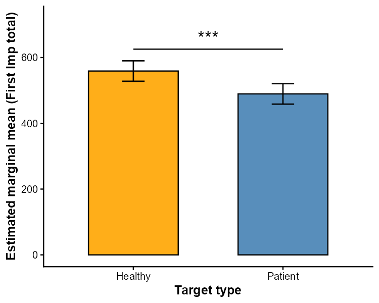

These results suggest that based solely on body movements and without any diagnostic information, participants from the general population formed more negative first impressions of individuals with schizophrenia than of healthy controls.

## 5.2 5.2 Movement results

### 5.2.1 5.2.1 Descriptive statistics of movement metrics by group

| Table 3 Descriptive statistics of movement metrics by group Metric | Table 3 Descriptive statistics of movement metrics by group CT | Table 3 Descriptive statistics of movement metrics by group SZ | Table 3 Descriptive statistics of movement metrics by group N_CT | Table 3 Descriptive statistics of movement metrics by group N_SZ |
| --- | --- | --- | --- | --- |
| mean_QoM | 0.358 (0.873) | -0.355 (0.690) | 20.00 | 20.00 |
| mean_amplitude_sum | 0.303 (0.868) | -0.312 (0.641) | 20.00 | 20.00 |
| mean_mean_speed | 0.277 (0.876) | -0.285 (0.673) | 20.00 | 20.00 |

Note. Values are M (SD) in standardized units. N_CT and N_SZ report the number of participants per group.

### 5.2.2 5.2.2 Group differences in movement metrics

| Table 4 Group comparisons on movement metrics Metric | Table 4 Group comparisons on movement metrics CT | Table 4 Group comparisons on movement metrics SZ | Table 4 Group comparisons on movement metrics Test | Table 4 Group comparisons on movement metrics Statistic | Table 4 Group comparisons on movement metrics p |
| --- | --- | --- | --- | --- | --- |
| mean_QoM | 0.358 (0.873) | -0.355 (0.690) | Welch t-test | 2.87 | .007** |
| mean_amplitude_sum | 0.303 (0.868) | -0.312 (0.641) | Welch t-test | 2.55 | .015* |
| mean_mean_speed | 0.277 (0.876) | -0.285 (0.673) | Welch t-test | 2.27 | .029* |

Note. CT and SZ columns are M (SD). The reported test depends on the assumption checks performed in the analysis notebook.  
* p < .05, ** p < .01, *** p < .001

```
## <p><strong>Figure 2. Group differences across movement metrics.</strong></p>
```

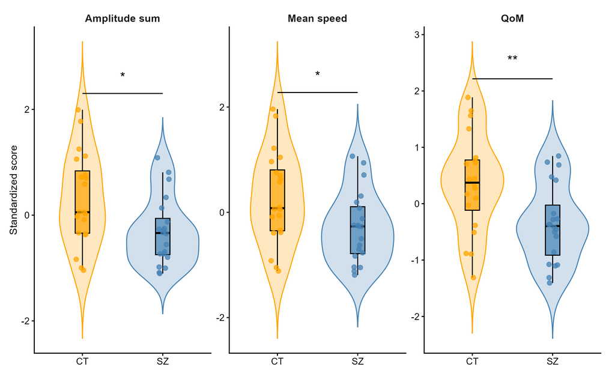

The observed differences in movement parameters indicate that the two groups differ in their motor behavior. In particular, individuals with schizophrenia display reduced or altered movement patterns compared to controls. These differences may constitute perceptible cues that influence the formation of first impressions.

## 5.3 5.3 Movement metrics and first impressions

### 5.3.1 5.3.1 Stimulus-level regression

A first analysis was performed at the stimulus level to summarize the association between the movement composite score and the first-impression total score.

| Table 5 Linear regression: first-impression total score predicted by the movement composite Predictor | Table 5 Linear regression: first-impression total score predicted by the movement composite b* | Table 5 Linear regression: first-impression total score predicted by the movement composite SE | Table 5 Linear regression: first-impression total score predicted by the movement composite t | Table 5 Linear regression: first-impression total score predicted by the movement composite p | Table 5 Linear regression: first-impression total score predicted by the movement composite R2 | Table 5 Linear regression: first-impression total score predicted by the movement composite R2_adj | Table 5 Linear regression: first-impression total score predicted by the movement composite F_stat | Table 5 Linear regression: first-impression total score predicted by the movement composite df_num | Table 5 Linear regression: first-impression total score predicted by the movement composite df_den | Table 5 Linear regression: first-impression total score predicted by the movement composite n |
| --- | --- | --- | --- | --- | --- | --- | --- | --- | --- | --- |
| Intercept | 321.96 | 4.90 | 65.68 | < .001*** | .41 | 0.39 | 25.90 | 1.00 | 38.00 | 40 |
| Movement composite (+1 SD) | 30.87 | 6.07 | 5.09 | < .001*** | .41 | 0.39 | 25.90 | 1.00 | 38.00 | 40 |

Note. This table summarizes the stimulus-level regression model.  
* p < .05, ** p < .01, *** p < .001

```
## <p><strong>Figure 3. First-impression total score plotted against each movement metric.</strong></p>
```

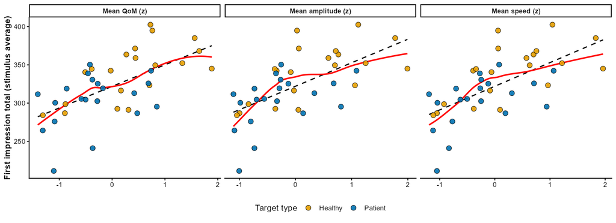

```
## <p><strong>Figure 4. First-impression total score plotted against the movement composite.</strong></p>
```

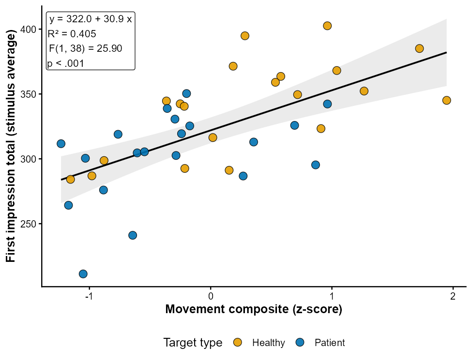

The results show a significant association between movement and first impressions, with higher levels of movement being associated with more positive evaluations. This suggests that movement characteristics serve as salient cues in the formation of rapid social judgments.

### 5.3.2 5.3.2 Linear mixed-effects model

A linear mixed-effects model was used for the main inferential analysis because the ratings were not independent: multiple observers rated multiple videos, and multiple ratings referred to the same stimuli. This model therefore accounts for repeated ratings while testing the contribution of target type and the movement composite.

| Table 6 Linear mixed-effects model coefficients Predictor | Table 6 Linear mixed-effects model coefficients b* | Table 6 Linear mixed-effects model coefficients SE | Table 6 Linear mixed-effects model coefficients t |
| --- | --- | --- | --- |
| Patient vs Healthy | -21.06 | 9.16 | -2.30 |
| Movement composite (+1 SD) | 25.78 | 5.73 | 4.50 |
| Presentation order | 0.28 | 0.83 | 0.34 |

Note. The mixed-effects model includes random intercepts for observers and videos.  
* p < .05, ** p < .01, *** p < .001

| Table 7 Linear mixed-effects model fit indices Index | Table 7 Linear mixed-effects model fit indices Value |
| --- | --- |
| Marginal R² | 0.09 |
| Conditional R² | 0.35 |
| N observations | 910.00 |

Note. Marginal R² refers to fixed effects only. Conditional R² refers to fixed and random effects combined.

Although the model identifies significant predictors, the proportion of explained variance remains moderate. This suggests that first impressions are likely influenced by additional factors not included in the present model.

# 6 6. Technical discussion

The project was split into Python and R components to keep the workflow readable and modular. Python was used for movement preprocessing and feature construction from landmark-based data, whereas R was used for statistical modeling and final reporting. This separation makes the project easier to inspect, rerun, and defend.

The repository is organized around a standard project structure with entry points (`main.ipynb`, `main.Rmd`), analysis notebooks, reusable source scripts, data files, and generated results. This organization matches the expected project logic described in the course guidelines.

The final report only displays outputs that were actually generated by the analysis pipeline. This choice keeps the document self-sufficient while avoiding unsupported manual transcription of numerical results, which is important for both evaluation and defense preparation.

# 7 7. Reproducibility

The repository contains:

- `main.ipynb` as the Python entry point,
- `main.Rmd` as the R entry point,
- `notebooks/` for analysis notebooks,
- `sources/` for reusable scripts/functions,
- `data/` for raw and processed files,
- `results/` for generated tables and figures.

To make the project easier to evaluate on another computer, required libraries should be listed in the first code cell of `main.ipynb` and in the setup chunk of `main.Rmd`, as explicitly requested in the course guidelines.

This report is intended to complement the repository by providing a compact, technical overview of the workflow and its main outputs.

[output not shown]